# ps1

## 1.6 5.2.4

```r
library("nycflights13")
library(tidyverse)
```

```r
airlines
```

```
## # A tibble: 16 x 2
##    carrier                        name
##      <chr>                       <chr>
##  1      9E           Endeavor Air Inc.
##  2      AA      American Airlines Inc.
##  3      AS        Alaska Airlines Inc.
##  4      B6             JetBlue Airways
##  5      DL        Delta Air Lines Inc.
##  6      EV    ExpressJet Airlines Inc.
##  7      F9      Frontier Airlines Inc.
##  8      FL AirTran Airways Corporation
##  9      HA      Hawaiian Airlines Inc.
## 10      MQ                   Envoy Air
## 11      OO       SkyWest Airlines Inc.
## 12      UA       United Air Lines Inc.
## 13      US             US Airways Inc.
## 14      VX              Virgin America
## 15      WN      Southwest Airlines Co.
## 16      YV          Mesa Airlines Inc.
```

```r
filter(flights, arr_delay >= 120)
```

```
## # A tibble: 10,200 x 19
##     year month   day dep_time sched_dep_time dep_delay arr_time
##    <int> <int> <int>    <int>          <int>     <dbl>    <int>
##  1  2013     1     1      811            630       101     1047
##  2  2013     1     1      848           1835       853     1001
##  3  2013     1     1      957            733       144     1056
##  4  2013     1     1     1114            900       134     1447
##  5  2013     1     1     1505           1310       115     1638
##  6  2013     1     1     1525           1340       105     1831
##  7  2013     1     1     1549           1445        64     1912
##  8  2013     1     1     1558           1359       119     1718
##  9  2013     1     1     1732           1630        62     2028
## 10  2013     1     1     1803           1620       103     2008
## # ... with 10,190 more rows, and 12 more variables: sched_arr_time <int>,
## #   arr_delay <dbl>, carrier <chr>, flight <int>, tailnum <chr>,
## #   origin <chr>, dest <chr>, air_time <dbl>, distance <dbl>, hour <dbl>,
## #   minute <dbl>, time_hour <dttm>
```

```r
filter(flights, dest %in% c("IAH","HOU"))
```

```
## # A tibble: 9,313 x 19
##     year month   day dep_time sched_dep_time dep_delay arr_time
##    <int> <int> <int>    <int>          <int>     <dbl>    <int>
##  1  2013     1     1      517            515         2      830
##  2  2013     1     1      533            529         4      850
##  3  2013     1     1      623            627        -4      933
##  4  2013     1     1      728            732        -4     1041
##  5  2013     1     1      739            739         0     1104
##  6  2013     1     1      908            908         0     1228
##  7  2013     1     1     1028           1026         2     1350
##  8  2013     1     1     1044           1045        -1     1352
##  9  2013     1     1     1114            900       134     1447
## 10  2013     1     1     1205           1200         5     1503
## # ... with 9,303 more rows, and 12 more variables: sched_arr_time <int>,
## #   arr_delay <dbl>, carrier <chr>, flight <int>, tailnum <chr>,
## #   origin <chr>, dest <chr>, air_time <dbl>, distance <dbl>, hour <dbl>,
## #   minute <dbl>, time_hour <dttm>
```

```r
filter(flights, carrier %in% c("UA","AA","DL"))
```

```
## # A tibble: 139,504 x 19
##     year month   day dep_time sched_dep_time dep_delay arr_time
##    <int> <int> <int>    <int>          <int>     <dbl>    <int>
##  1  2013     1     1      517            515         2      830
##  2  2013     1     1      533            529         4      850
##  3  2013     1     1      542            540         2      923
##  4  2013     1     1      554            600        -6      812
##  5  2013     1     1      554            558        -4      740
##  6  2013     1     1      558            600        -2      753
##  7  2013     1     1      558            600        -2      924
##  8  2013     1     1      558            600        -2      923
##  9  2013     1     1      559            600        -1      941
## 10  2013     1     1      559            600        -1      854
## # ... with 139,494 more rows, and 12 more variables: sched_arr_time <int>,
## #   arr_delay <dbl>, carrier <chr>, flight <int>, tailnum <chr>,
## #   origin <chr>, dest <chr>, air_time <dbl>, distance <dbl>, hour <dbl>,
## #   minute <dbl>, time_hour <dttm>
```

```r
filter(flights, month %in% 7:9)
```

```
## # A tibble: 86,326 x 19
##     year month   day dep_time sched_dep_time dep_delay arr_time
##    <int> <int> <int>    <int>          <int>     <dbl>    <int>
##  1  2013     7     1        1           2029       212      236
##  2  2013     7     1        2           2359         3      344
##  3  2013     7     1       29           2245       104      151
##  4  2013     7     1       43           2130       193      322
##  5  2013     7     1       44           2150       174      300
##  6  2013     7     1       46           2051       235      304
##  7  2013     7     1       48           2001       287      308
##  8  2013     7     1       58           2155       183      335
##  9  2013     7     1      100           2146       194      327
## 10  2013     7     1      100           2245       135      337
## # ... with 86,316 more rows, and 12 more variables: sched_arr_time <int>,
## #   arr_delay <dbl>, carrier <chr>, flight <int>, tailnum <chr>,
## #   origin <chr>, dest <chr>, air_time <dbl>, distance <dbl>, hour <dbl>,
## #   minute <dbl>, time_hour <dttm>
```

```r
filter(flights, arr_delay > 120, dep_delay <= 0)
```

```
## # A tibble: 29 x 19
##     year month   day dep_time sched_dep_time dep_delay arr_time
##    <int> <int> <int>    <int>          <int>     <dbl>    <int>
##  1  2013     1    27     1419           1420        -1     1754
##  2  2013    10     7     1350           1350         0     1736
##  3  2013    10     7     1357           1359        -2     1858
##  4  2013    10    16      657            700        -3     1258
##  5  2013    11     1      658            700        -2     1329
##  6  2013     3    18     1844           1847        -3       39
##  7  2013     4    17     1635           1640        -5     2049
##  8  2013     4    18      558            600        -2     1149
##  9  2013     4    18      655            700        -5     1213
## 10  2013     5    22     1827           1830        -3     2217
## # ... with 19 more rows, and 12 more variables: sched_arr_time <int>,
## #   arr_delay <dbl>, carrier <chr>, flight <int>, tailnum <chr>,
## #   origin <chr>, dest <chr>, air_time <dbl>, distance <dbl>, hour <dbl>,
## #   minute <dbl>, time_hour <dttm>
```

```r
filter(flights, dep_delay >= 60, dep_delay <= 0)
```

```
## # A tibble: 0 x 19
## # ... with 19 variables: year <int>, month <int>, day <int>,
## #   dep_time <int>, sched_dep_time <int>, dep_delay <dbl>, arr_time <int>,
## #   sched_arr_time <int>, arr_delay <dbl>, carrier <chr>, flight <int>,
## #   tailnum <chr>, origin <chr>, dest <chr>, air_time <dbl>,
## #   distance <dbl>, hour <dbl>, minute <dbl>, time_hour <dttm>
```

```r
filter(flights, dep_delay >= 60, (dep_delay-arr_delay)> 60)
```

```
## # A tibble: 30 x 19
##     year month   day dep_time sched_dep_time dep_delay arr_time
##    <int> <int> <int>    <int>          <int>     <dbl>    <int>
##  1  2013     1     3     1950           1845        65     2228
##  2  2013    11    12     2216           2015       121       51
##  3  2013    12    27     1936           1830        66     2204
##  4  2013     2    23     1226            900       206     1746
##  5  2013     2    26     1000            900        60     1513
##  6  2013     2    27     2006           1830        96     2238
##  7  2013     3     1     1528            920       368     1738
##  8  2013     3     1     1738           1545       113     1958
##  9  2013     3     1     1827           1620       127     2106
## 10  2013     3     1     1929           1645       164     2141
## # ... with 20 more rows, and 12 more variables: sched_arr_time <int>,
## #   arr_delay <dbl>, carrier <chr>, flight <int>, tailnum <chr>,
## #   origin <chr>, dest <chr>, air_time <dbl>, distance <dbl>, hour <dbl>,
## #   minute <dbl>, time_hour <dttm>
```

```r
filter(flights, dep_delay >= 60, (dep_delay-arr_delay)> 60)
```

```
## # A tibble: 30 x 19
##     year month   day dep_time sched_dep_time dep_delay arr_time
##    <int> <int> <int>    <int>          <int>     <dbl>    <int>
##  1  2013     1     3     1950           1845        65     2228
##  2  2013    11    12     2216           2015       121       51
##  3  2013    12    27     1936           1830        66     2204
##  4  2013     2    23     1226            900       206     1746
##  5  2013     2    26     1000            900        60     1513
##  6  2013     2    27     2006           1830        96     2238
##  7  2013     3     1     1528            920       368     1738
##  8  2013     3     1     1738           1545       113     1958
##  9  2013     3     1     1827           1620       127     2106
## 10  2013     3     1     1929           1645       164     2141
## # ... with 20 more rows, and 12 more variables: sched_arr_time <int>,
## #   arr_delay <dbl>, carrier <chr>, flight <int>, tailnum <chr>,
## #   origin <chr>, dest <chr>, air_time <dbl>, distance <dbl>, hour <dbl>,
## #   minute <dbl>, time_hour <dttm>
```

```r
filter(flights, dep_time >= 2400 , dep_time <= 600)
```

```
## # A tibble: 0 x 19
## # ... with 19 variables: year <int>, month <int>, day <int>,
## #   dep_time <int>, sched_dep_time <int>, dep_delay <dbl>, arr_time <int>,
## #   sched_arr_time <int>, arr_delay <dbl>, carrier <chr>, flight <int>,
## #   tailnum <chr>, origin <chr>, dest <chr>, air_time <dbl>,
## #   distance <dbl>, hour <dbl>, minute <dbl>, time_hour <dttm>
```

2. Another useful dplyr filtering helper is between(). What does it do? Can you use it to simplify the code needed to answer the previous challenges?

It tests if valeus in a numeric vector fall in specified range.

```r
?between()
filter(flights,between(dep_time,2359,601))
```

```
## # A tibble: 0 x 19
## # ... with 19 variables: year <int>, month <int>, day <int>,
## #   dep_time <int>, sched_dep_time <int>, dep_delay <dbl>, arr_time <int>,
## #   sched_arr_time <int>, arr_delay <dbl>, carrier <chr>, flight <int>,
## #   tailnum <chr>, origin <chr>, dest <chr>, air_time <dbl>,
## #   distance <dbl>, hour <dbl>, minute <dbl>, time_hour <dttm>
```

3. How many flights have a missing dep_time? What other variables are missing? What might these rows represent? 8255 flights have a missing dep_time. dep_delay, arr_time, arr_delay, tailnum, and air_time have missings. They might represent some flights that have been canceled and some flights that we failed to record the data of.

```r
dep_time_na <- filter(flights,is.na(dep_time))
nrow(dep_time_na)
```

```
## [1] 8255
```

```r
map_dbl(flights, ~sum(is.na(.x)))
```

```
##           year          month            day       dep_time sched_dep_time
##              0              0              0           8255              0
##      dep_delay       arr_time sched_arr_time      arr_delay        carrier
##           8255           8713              0           9430              0
##         flight        tailnum         origin           dest       air_time
##              0           2512              0              0           9430
##       distance           hour         minute      time_hour
##              0              0              0              0
```

```r
?map_dbl
```

4. Why is NA ˆ 0 not missing? Why is NA | TRUE not missing? Why is FALSE & NA not missing? Can you figure out the general rule? (NA * 0 is a tricky counterexample!)

NA^0 returns 1, because anthing to the power of 0 is 1. NA | TRUE returns TRUE because the second part is true and R is testing either of them is TRUE FALSE & NA returns FALSE because r is testing if both are True, if one can be tested and because the first part is False, it returns False as its value

```r
NA^0
```

```
## [1] 1
```

```r
NA | TRUE
```

```
## [1] TRUE
```

```r
FALSE & NA
```

```
## [1] FALSE
```

## 1.7 5.3.1

1. How could you use arrange() to sort all missing values to the start? (Hint: use is.na()).

```r
flights %>%
arrange(!is.na(flights$tailnum), flights$tailnum)
```

```
## # A tibble: 336,776 x 19
##     year month   day dep_time sched_dep_time dep_delay arr_time
##    <int> <int> <int>    <int>          <int>     <dbl>    <int>
##  1  2013     1     2       NA           1545        NA       NA
##  2  2013     1     2       NA           1601        NA       NA
##  3  2013     1     3       NA            857        NA       NA
##  4  2013     1     3       NA            645        NA       NA
##  5  2013     1     4       NA            845        NA       NA
##  6  2013     1     4       NA           1830        NA       NA
##  7  2013     1     5       NA            840        NA       NA
##  8  2013     1     7       NA            820        NA       NA
##  9  2013     1     8       NA           1645        NA       NA
## 10  2013     1     9       NA            755        NA       NA
## # ... with 336,766 more rows, and 12 more variables: sched_arr_time <int>,
## #   arr_delay <dbl>, carrier <chr>, flight <int>, tailnum <chr>,
## #   origin <chr>, dest <chr>, air_time <dbl>, distance <dbl>, hour <dbl>,
## #   minute <dbl>, time_hour <dttm>
```

2. Sort flights to find the most delayed flights by arrival time.

```r
arrange(flights, arr_time, desc(dep_delay))
```

```
## # A tibble: 336,776 x 19
##     year month   day dep_time sched_dep_time dep_delay arr_time
##    <int> <int> <int>    <int>          <int>     <dbl>    <int>
##  1  2013     3     8     2212           1539       393        1
##  2  2013     2    11     2159           1630       329        1
##  3  2013     8     1     2157           1734       263        1
##  4  2013    11    27     2243           1900       223        1
##  5  2013     9    11     2209           1830       219        1
##  6  2013     9    12     2109           1730       219        1
##  7  2013    12    17     2253           1920       213        1
##  8  2013     7    21     2203           1840       203        1
##  9  2013     6    10     2051           1729       202        1
## 10  2013     6    24     2018           1711       187        1
## # ... with 336,766 more rows, and 12 more variables: sched_arr_time <int>,
## #   arr_delay <dbl>, carrier <chr>, flight <int>, tailnum <chr>,
## #   origin <chr>, dest <chr>, air_time <dbl>, distance <dbl>, hour <dbl>,
## #   minute <dbl>, time_hour <dttm>
```

```r
#or
arrange(arrange(flights, desc(dep_delay)),arr_time)
```

```
## # A tibble: 336,776 x 19
##     year month   day dep_time sched_dep_time dep_delay arr_time
##    <int> <int> <int>    <int>          <int>     <dbl>    <int>
##  1  2013     3     8     2212           1539       393        1
##  2  2013     2    11     2159           1630       329        1
##  3  2013     8     1     2157           1734       263        1
##  4  2013    11    27     2243           1900       223        1
##  5  2013     9    11     2209           1830       219        1
##  6  2013     9    12     2109           1730       219        1
##  7  2013    12    17     2253           1920       213        1
##  8  2013     7    21     2203           1840       203        1
##  9  2013     6    10     2051           1729       202        1
## 10  2013     6    24     2018           1711       187        1
## # ... with 336,766 more rows, and 12 more variables: sched_arr_time <int>,
## #   arr_delay <dbl>, carrier <chr>, flight <int>, tailnum <chr>,
## #   origin <chr>, dest <chr>, air_time <dbl>, distance <dbl>, hour <dbl>,
## #   minute <dbl>, time_hour <dttm>
```

3. Find the flights that left earliest relative to their scheduled departure.

I printed the first 10 flights that left earliest relative to their scheduled departure.

```r
print(head(arrange(flights, dep_delay), 10))
```

```
## # A tibble: 10 x 19
##     year month   day dep_time sched_dep_time dep_delay arr_time
##    <int> <int> <int>    <int>          <int>     <dbl>    <int>
##  1  2013    12     7     2040           2123       -43       40
##  2  2013     2     3     2022           2055       -33     2240
##  3  2013    11    10     1408           1440       -32     1549
##  4  2013     1    11     1900           1930       -30     2233
##  5  2013     1    29     1703           1730       -27     1947
##  6  2013     8     9      729            755       -26     1002
##  7  2013    10    23     1907           1932       -25     2143
##  8  2013     3    30     2030           2055       -25     2213
##  9  2013     3     2     1431           1455       -24     1601
## 10  2013     5     5      934            958       -24     1225
## # ... with 12 more variables: sched_arr_time <int>, arr_delay <dbl>,
## #   carrier <chr>, flight <int>, tailnum <chr>, origin <chr>, dest <chr>,
## #   air_time <dbl>, distance <dbl>, hour <dbl>, minute <dbl>,
## #   time_hour <dttm>
```

4. Sort flights to find the shortest amount of time actually in the air.

Assume the actually time in the air is air_time, then we have:

```r
print(head(arrange(flights, air_time), 2))
```

```
## # A tibble: 2 x 19
##    year month   day dep_time sched_dep_time dep_delay arr_time
##   <int> <int> <int>    <int>          <int>     <dbl>    <int>
## 1  2013     1    16     1355           1315        40     1442
## 2  2013     4    13      537            527        10      622
## # ... with 12 more variables: sched_arr_time <int>, arr_delay <dbl>,
## #   carrier <chr>, flight <int>, tailnum <chr>, origin <chr>, dest <chr>,
## #   air_time <dbl>, distance <dbl>, hour <dbl>, minute <dbl>,
## #   time_hour <dttm>
```

## 1.8 5.4.1

1. Brainstorm as many ways as possible to select dep_time, dep_delay, arr_time, and arr_delay from flights.

```r
names(flights)
```

```
##  [1] "year"           "month"          "day"            "dep_time"
##  [5] "sched_dep_time" "dep_delay"      "arr_time"       "sched_arr_time"
##  [9] "arr_delay"      "carrier"        "flight"         "tailnum"
## [13] "origin"         "dest"           "air_time"       "distance"
## [17] "hour"           "minute"         "time_hour"
```

```r
select(flights, dep_time, dep_delay, arr_time, arr_delay)
```

```
## # A tibble: 336,776 x 4
##    dep_time dep_delay arr_time arr_delay
##       <int>     <dbl>    <int>     <dbl>
##  1      517         2      830        11
##  2      533         4      850        20
##  3      542         2      923        33
##  4      544        -1     1004       -18
##  5      554        -6      812       -25
##  6      554        -4      740        12
##  7      555        -5      913        19
##  8      557        -3      709       -14
##  9      557        -3      838        -8
## 10      558        -2      753         8
## # ... with 336,766 more rows
```

```r
select(flights, -(year:day),-sched_dep_time, -sched_arr_time, -(carrier:time_hour))
```

```
## # A tibble: 336,776 x 4
##    dep_time dep_delay arr_time arr_delay
##       <int>     <dbl>    <int>     <dbl>
##  1      517         2      830        11
##  2      533         4      850        20
##  3      542         2      923        33
##  4      544        -1     1004       -18
##  5      554        -6      812       -25
##  6      554        -4      740        12
##  7      555        -5      913        19
##  8      557        -3      709       -14
##  9      557        -3      838        -8
## 10      558        -2      753         8
## # ... with 336,766 more rows
```

```r
select(flights, -(year:day),-contains("_dep_time"), -(carrier:time_hour))
```

```
## # A tibble: 336,776 x 5
##    dep_time dep_delay arr_time sched_arr_time arr_delay
##       <int>     <dbl>    <int>          <int>     <dbl>
##  1      517         2      830            819        11
##  2      533         4      850            830        20
##  3      542         2      923            850        33
##  4      544        -1     1004           1022       -18
##  5      554        -6      812            837       -25
##  6      554        -4      740            728        12
##  7      555        -5      913            854        19
##  8      557        -3      709            723       -14
##  9      557        -3      838            846        -8
## 10      558        -2      753            745         8
## # ... with 336,766 more rows
```

```r
select(flights, contains("_"), -contains("sched"), -air_time, -time_hour)
```

```
## # A tibble: 336,776 x 4
##    dep_time dep_delay arr_time arr_delay
##       <int>     <dbl>    <int>     <dbl>
##  1      517         2      830        11
##  2      533         4      850        20
##  3      542         2      923        33
##  4      544        -1     1004       -18
##  5      554        -6      812       -25
##  6      554        -4      740        12
##  7      555        -5      913        19
##  8      557        -3      709       -14
##  9      557        -3      838        -8
## 10      558        -2      753         8
## # ... with 336,766 more rows
```

2. What happens if you include the name of a variable multiple times in a select() call? select(flights, dep_time) The code would return the same result as if we only include the name of the variable once.
3. What does the one_of() function do? Why might it be helpful in conjunction with this vector? vars <- c(“year”, “month”, “day”, “dep_delay”, “arr_delay”) It select the data from variables in character vector that includes character names of variables.
4. Does the result of running the following code surprise you? How do the select helpers deal with case by default? How can you change that default? No it doesn’t surprise me. Because the default setting of case is ignore.case = TRUE in select helpers, the command selects variables that contain word “TIME” no matter of upper- or lower- case. In order to select variables that only contain upper-case “TIME”, we do:

```r
select(flights, contains("TIME",ignore.case = FALSE))
```

Because the imported data sets have all variables names in lower case, the resulting data set after selection would be empty.

## 1.9 5.5.2

1. Currently dep_time and sched_dep_time are convenient to look at, but hard to compute with because they’re not really continuous numbers. Convert them to a more convenient representation of number of minutes since midnight.

```r
mutate(flights,
  dep_hour = dep_time %/% 100,
  dep_minute = dep_time %% 100,
  dep_time2 = hour  * 60 + minute,
  sched_dep_time2 = (sched_dep_time %/% 100) * 60 + (sched_dep_time %% 100)
)
```

```
## # A tibble: 336,776 x 23
##     year month   day dep_time sched_dep_time dep_delay arr_time
##    <int> <int> <int>    <int>          <int>     <dbl>    <int>
##  1  2013     1     1      517            515         2      830
##  2  2013     1     1      533            529         4      850
##  3  2013     1     1      542            540         2      923
##  4  2013     1     1      544            545        -1     1004
##  5  2013     1     1      554            600        -6      812
##  6  2013     1     1      554            558        -4      740
##  7  2013     1     1      555            600        -5      913
##  8  2013     1     1      557            600        -3      709
##  9  2013     1     1      557            600        -3      838
## 10  2013     1     1      558            600        -2      753
## # ... with 336,766 more rows, and 16 more variables: sched_arr_time <int>,
## #   arr_delay <dbl>, carrier <chr>, flight <int>, tailnum <chr>,
## #   origin <chr>, dest <chr>, air_time <dbl>, distance <dbl>, hour <dbl>,
## #   minute <dbl>, time_hour <dttm>, dep_hour <dbl>, dep_minute <dbl>,
## #   dep_time2 <dbl>, sched_dep_time2 <dbl>
```

2. Compare air_time with arr_time - dep_time. What do you expect to see? What do you see? What do you need to do to fix it?

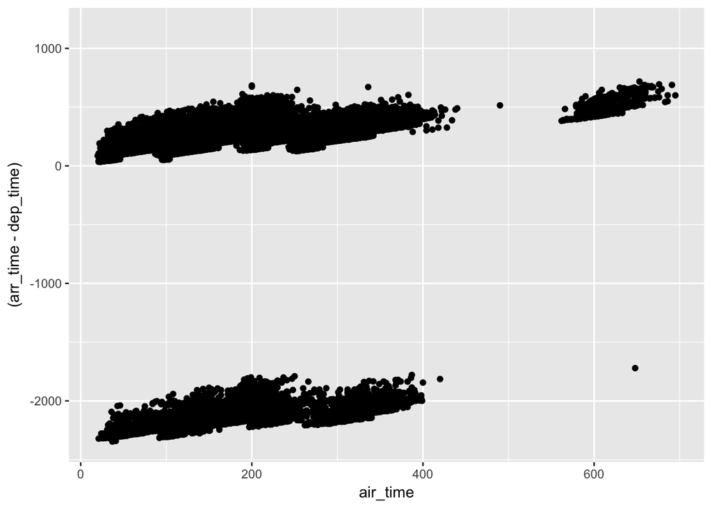

```r
ggplot(flights, aes(x=air_time, y=(arr_time - dep_time))) +
  geom_point()
```

```r
flights_temp <- transmute(flights,
  arr_time2 = (arr_time %/% 100) * 60 + (arr_time %% 100),
  dep_time2 = (dep_time %/% 100) * 60 + (dep_time %% 100),
  arr_time2-dep_time2,
  air_time,
  (arr_time2 - dep_time2) - air_time
)

flights_temp
```

```
## # A tibble: 336,776 x 5
##    arr_time2 dep_time2 `arr_time2 - dep_time2` air_time
##        <dbl>     <dbl>                   <dbl>    <dbl>
##  1       510       317                     193      227
##  2       530       333                     197      227
##  3       563       342                     221      160
##  4       604       344                     260      183
##  5       492       354                     138      116
##  6       460       354                     106      150
##  7       553       355                     198      158
##  8       429       357                      72       53
##  9       518       357                     161      140
## 10       473       358                     115      138
## # ... with 336,766 more rows, and 1 more variables: `(arr_time2 -
## #   dep_time2) - air_time` <dbl>
```

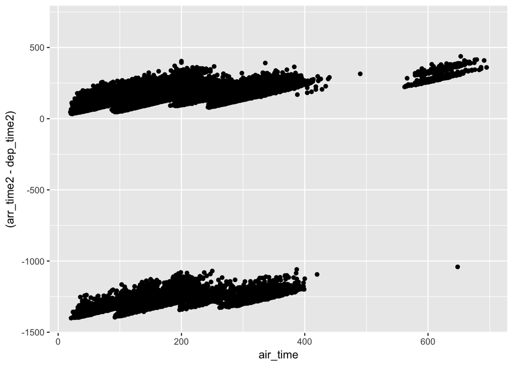

```r
ggplot(flights_temp, aes(x=air_time, y=(arr_time2 - dep_time2))) +
  geom_point()
```

3. Implement your fix. Remake the plot from the previous question.

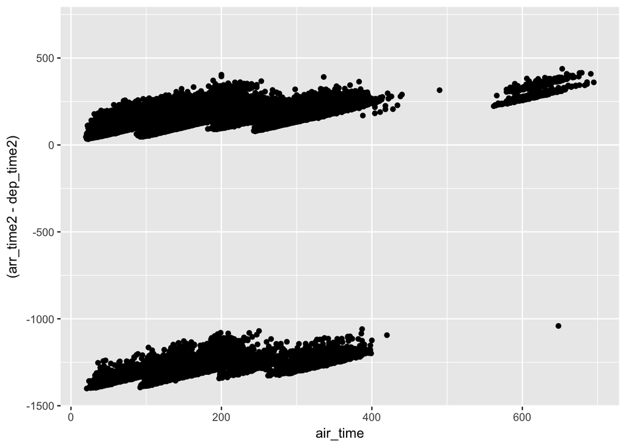

```r
flights2 <- transmute(flights,
  arr_time2 = (arr_time %/% 100) * 60 + (arr_time %% 100),
  dep_time2 = (dep_time %/% 100) * 60 + (dep_time %% 100),
  arr_time2-dep_time2,
  air_time,
  (arr_time2 - dep_time2) - air_time
)
ggplot(flights2, aes(x=air_time, y=(arr_time2 - dep_time2))) +
  geom_point()
```

4. Suggest and justify with words an error tolerance in minutes, meaning that if air_time is too far off from arr_time - dep_time then we assume one of the columns contains an error. After implementing your fix, what fraction of observations still appear to have an error?

because the difference between arrival time and departure time contain the time of flight in the air, which is the major part of the air_time. If air_time is far from (arr_time - dep_time), one of them might contain errors.

5. Compare dep_time, sched_dep_time, and dep_delay. How would you expect those three numbers to be related? dep_delay equals to the difference between dep_time and sched_dep_time

```r
select(flights,dep_time, sched_dep_time, dep_delay )
```

6. Find the 10 most delayed flights using a ranking function. How do you want to handle ties? Carefully read the documentation for min_rank().

I assume that when a flight got delayed, it’s delayed at both depature and at arrival. At the same time I took into consideration of the gains during the time in the air. The less gains, the more delayed the flight is considered to be, taking other variables constant.

The 10 most delayed flights are shown below:

```r
print((arrange(flights, -dep_delay, -arr_delay, (dep_delay - arr_delay))), 10)
```

```
## # A tibble: 336,776 x 19
##     year month   day dep_time sched_dep_time dep_delay arr_time
##    <int> <int> <int>    <int>          <int>     <dbl>    <int>
##  1  2013     1     9      641            900      1301     1242
##  2  2013     6    15     1432           1935      1137     1607
##  3  2013     1    10     1121           1635      1126     1239
##  4  2013     9    20     1139           1845      1014     1457
##  5  2013     7    22      845           1600      1005     1044
##  6  2013     4    10     1100           1900       960     1342
##  7  2013     3    17     2321            810       911      135
##  8  2013     6    27      959           1900       899     1236
##  9  2013     7    22     2257            759       898      121
## 10  2013    12     5      756           1700       896     1058
## # ... with 336,766 more rows, and 12 more variables: sched_arr_time <int>,
## #   arr_delay <dbl>, carrier <chr>, flight <int>, tailnum <chr>,
## #   origin <chr>, dest <chr>, air_time <dbl>, distance <dbl>, hour <dbl>,
## #   minute <dbl>, time_hour <dttm>
```

```r
#or
flights_p <- transmute(flights, dep_delay,arr_delay, gains=(arr_delay - dep_delay))
arrange(flights_p, -dep_delay, -arr_delay, gains)
```

```
## # A tibble: 336,776 x 3
##    dep_delay arr_delay gains
##        <dbl>     <dbl> <dbl>
##  1      1301      1272   -29
##  2      1137      1127   -10
##  3      1126      1109   -17
##  4      1014      1007    -7
##  5      1005       989   -16
##  6       960       931   -29
##  7       911       915     4
##  8       899       850   -49
##  9       898       895    -3
## 10       896       878   -18
## # ... with 336,766 more rows
```

7. What does 1:3 + 1:10 return? Why?

It returns that “longer object length is not a multiple of shorter object length”. Because “+” is a vecterized function, when we add two object, they should have the same length or one should be a multiple of the other.

```r
1:3 + 1:6
```

```
## [1] 2 4 6 5 7 9
```

+is a “vectorized function” because it takes one or morevectors and returns another vector

# 2 Public Sector Application: Flight Data

An international trade organization is hosting a two-day convention in Chicago in 2019. The mayor’s tourism office has asked for some planning help based on historical data from 2016.

## 2.1 Download BTS data

• Download files for the 2016 calendar year data here: • Read it into R using chi.flights <- read_csv(“data.csv”) and use the bind_rows command to stitch together the monthly files into a yearlong file

```r
setwd("~/Desktop/BTS data/") # Set the working directory

listcsv <- dir(pattern = "*.csv",full.names = FALSE) # list file names
print(listcsv) #file names are not read in correctly, month 10,11,12 are read in before month 3-9, but it will be corrected later
```

```
##  [1] "1.csv"  "10.csv" "11.csv" "12.csv" "2.csv"  "3.csv"  "4.csv"
##  [8] "5.csv"  "6.csv"  "7.csv"  "8.csv"  "9.csv"
```

```r
chi.flights <- ""
month <- list()
for (i in 1:12){
month[[i]] <- read.csv(listcsv[i],header=TRUE)
chi.flights <- rbind(chi.flights, month[[i]])
}
chi.flights$MONTH <- as.numeric(chi.flights$MONTH) #change data type of month into numeric in order to sort the data set by month.
chi.flights  <- arrange(chi.flights, MONTH) #sort data set by month

lowercase.names <- tolower(colnames(chi.flights)) #to set variable names lower case
colnames(chi.flights) <- lowercase.names

tail(chi.flights, 10) #last row of data set is empty: either NA or no entry
```

```
##        year month day_of_month day_of_week    fl_date unique_carrier
## 675814 2016    12            2           5 2016-12-02             DL
## 675815 2016    12            3           6 2016-12-03             DL
## 675816 2016    12            3           6 2016-12-03             DL
## 675817 2016    12            3           6 2016-12-03             DL
## 675818 2016    12            3           6 2016-12-03             DL
## 675819 2016    12            3           6 2016-12-03             DL
## 675820 2016    12            3           6 2016-12-03             DL
## 675821 2016    12            3           6 2016-12-03             DL
## 675822 2016    12            3           6 2016-12-03             DL
## 675823         NA                                <NA>           <NA>
##        airline_id carrier tail_num origin   origin_city_name
## 675814      19790      DL   N360NB    SLC Salt Lake City, UT
## 675815      19790      DL   N957DL    ORD        Chicago, IL
## 675816      19790      DL   N912DE    DTW        Detroit, MI
```

[output cut: 40 more lines]

```r
chi.flights <- head(chi.flights, -1)  #remove the last row, which is empty
```

## 2.2 Data Description

1. What is the unique identifier for each flight in the dataset?

We can identify each flight by their date of departure, unique airline carrier ID, tail number, a departure airport, and an arrival airport.

2. R has six description methods: print, head, str, glimpse, View, summary. Apply them to chi_flights

```r
library(nycflights13)
library(tidyverse)
```

print(chi.flights) #prints data set and returns invisibly head(chi.flights) #head(x, n) returns the first part of the data set x. n is the size of the data str(chi.flights) #returns the internal structure of the data glimpse(chi.flights) #returns a glimpse of the data in a transposed version of print. Compared to str(), it shows as much data ss possible. View(chi.flights) #It opens a spreadsheet-style data viewer summary(chi.flights) #returns summary of the data set and its variables

#### 1. Are any of the methods redundant, in the sense that you don’t learn anything from these commands that you didn’t already know from the prior methods? Make a list of the non-redundant methods

```r
(method.nonredundant <- list("print", "str", "summary"))
```

```
## [[1]]
## [1] "print"
##
## [[2]]
## [1] "str"
##
## [[3]]
## [1] "summary"
```

## 2.3 Data Validation

1. You should have 675822 rows when you downloaded data for Illinois. Load the package testthat and then test that you have this many rows using the command test_that(expect_equal(nrows(data),675822))

```r
#install.packages("testthat")
library(testthat)
test_that("expected number of rows is 675822", expect_equal(nrow(chi.flights),675822)) #When run from the command line, tests return NULL if all expectations are met, otherwise it raises an error
```

2. Because of the conditions you put into the webform, all flights should be to or from Illinois airports. Let’s check this.

By filtering the data with conditions origin_state_nm == “Illinois” | dest_state_nm == “Illinois”, r would delete rows that do not satisfy these contidions. If we count the number of rows of the filtered data set, it is still 675822, which means all rows satisfied the condition and no rows was deleted.

```r
(nrow(filter(chi.flights, origin_state_nm == "Illinois" | dest_state_nm == "Illinois")))
```

```
## [1] 675822
```

3. Drop flights to Midway and Ohare. How many flights are left?

There are 344131 flights left.

```r
(nrow(filter(chi.flights, dest != "MDW" & dest != "ORD")))
```

```
## [1] 344131
```

4. Among flights whose origin or destination is not Midway or Ohare, what are the five most common origins? What are the five most common destinations? Where are these cities? Are these origins and destinations inside or outside Illinois? Can you explain why these are the most common origins and destinations?

From the bar chart, we can see the five most common destinations or origins are ATL, PIA, MLI, BMI, and DTW. They are located in Atlanta, Peoria, Moline, Bloomington, and Detroit. PIA and MLI are the two airports that located inside Illinois and ATL, BMI, and DTW are outside Illinois.

Becaue Chicago is a big hub city, other than MDW, PIA and MLI are the nearest airports to ORD, thus it helps to split the traffic.ATL and DTW are one of those major ports of entry into the US and they are the main layover airports when people travel between Chicago and other domestic or international destinations.

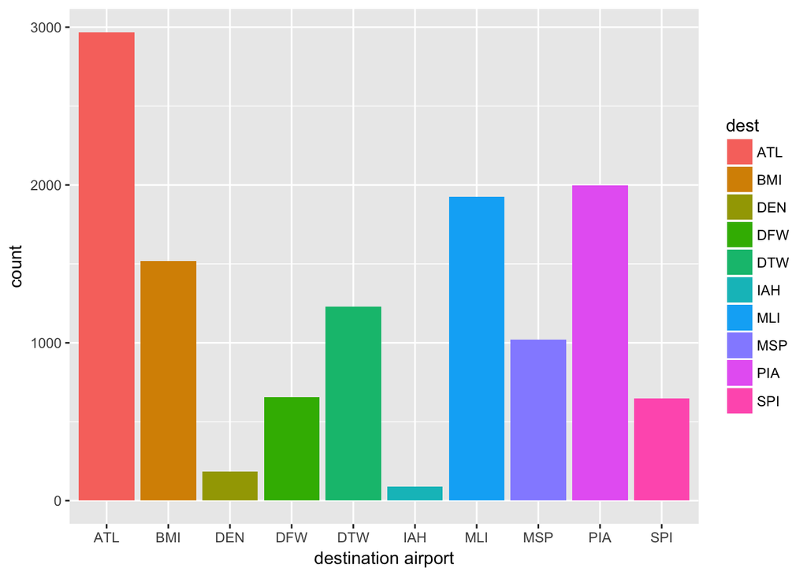

```r
chi.flights2 <- filter(chi.flights, dest != "MDW" & dest != "ORD" & origin != "MDW" & origin != "ORD")
ggplot(chi.flights2, aes(x = dest, fill = dest)) +
  geom_bar() +
  labs(x = "destination airport")
```

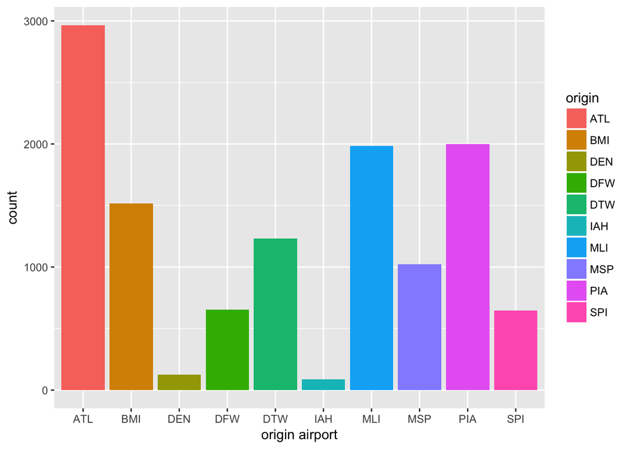

```r
ggplot(chi.flights2, aes(x = origin, fill = origin)) +
  geom_bar() +
  labs(x = "origin airport")
```

5. Next, limit the sample to flights to or from Midway and Ohare. How many rows do you think the dataset should have, approximately? Find at least two websites that estimate the number of flights into each airport. Do these estimates agree with what is in the BTS dataset? Do these estimates agree with each other? If they disagree, why do you think they disagree?

The data set is expected to have (675822 - 12240) = 663582 row, where 675822 is number of all flights to or from Illinois airports, which is nrow(chi.flights), and 12240 is the number of flights whose origin or destination is not Midway or Ohare, which equals to nrow(chi.flights2). The difference of them is the expected number of flights that fly to or from Midway and Ohare.

1. Chicago O’Hare (881,933 total flight operations in 2014), Chicago Midway (249,252) https://www.usatoday.com/story/travel/flights/todayinthesky/2015/01/21/chicago-ohare-retakes-worlds-busiest-title--sort-/22125499/
2. “The Federal Aviation Administration reported Thursday that total flight operations at O’Hare were down 0.9 percent to 867,635 in 2016, from 875,136 in 2015. At Midway, flight numbers were down 0.2 percent to 253,046 from 253,519 in 2015.” http://www.chicagotribune.com/news/ct-ohare-midway-flights-down-0127-20170126-story.html

```r
nrow(chi.flights2)
```

```
## [1] 12240
```

```r
chi.flights3 <- filter(chi.flights, dest == "MDW" | dest == "ORD" | origin == "MDW" | origin == "ORD")
nrow(chi.flights3)
```

```
## [1] 663582
```

6. Google to figure out the three highest-volume airlines at Ohare and the three highest-volume airlines out of Midway. Does this agree with what you find in the BTS data? If they disagree, why do you think they disagree? From the bar chart, we can tell the three highest-volume airlines are WN, UA, and AA

In the case of ORD the highest volumes are United Airlines, American Airlines, and Spirit. https://simple.wikipedia.org/wiki/O%27Hare_International_Airport http://www.chicagobusiness.com/article/20151205/ISSUE01/312059993/can-you-guess-whats-the-third-biggest-airline-at-ohare

For MDW Southwest is the first http://www.chicagotribune.com/news/ct-midway-southwest-met-20151016-story.html

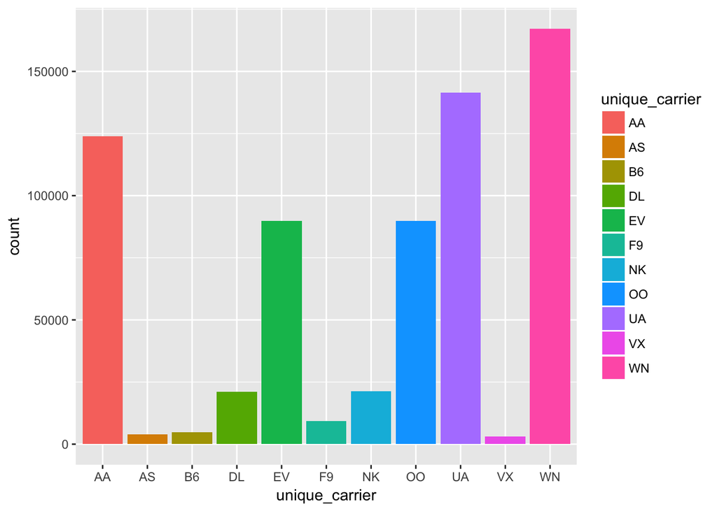

```r
ggplot(chi.flights, aes(x= unique_carrier)) +
  geom_bar(aes(fill=unique_carrier))
```